# A. INTRODUCTION

Python adalah bahasa pemrograman tingkat tinggi yang memiliki tipe interpreter.

Note :

Berdasarkan cara eksekusinya, bahasa pemrograman terbagi 2 :

1. Interpreter
- Interpreter adalah jenis bahasa pemrograman yang mengeksekusi kode secara baris per baris, atau per-statement. Cara kerjanya, interpreter langsung menerjemahkan kode per-statement ke dalam bahasa mesin. Prosesnya dilakukan baris per baris atau per statement, tanpa harus mengumpulkan keseluruhan program terlebih dahulu.
1. Compiler
- Compiler adalah sebuah program yang berfungsi untuk menerjemahkan kode program yang ditulis dalam sebuah file dengan cara mengumpulkannya secara keseluruhan, kemudian dianalisa untuk disusun kembali menjadi sebuah program.

.

.

# B. CARA MENJALANKAN PYTHON

Untuk menjalankan Python, kita harus menginstall dulu interpretter dari Python yang bisa didownload di https://www.python.org.

Cara menjalankan Python ada beberapa cara, yaitu melalui IDE/Text Editor dan melalui Python Shell atau IDLE bawaan Python.

Note :

- IDLE bisa juga dibuka melalui command prompt, yaitu dengan mengetikan command : python
- Untuk menjalankan program Python yang telah dibuat melalui command prompt, ketikan command berikut : python (spasi) nama_file.py

.

.

# C. KONSEP INDENTASI

Ada sebuah keunikan dalam Python. Untuk menuliskan code-block Python memanfaatkan indentasi.

Sehingga tidak seperti bahasa pemrograman lain, indentasi pada Python sangat-sangat berpengaruh terhadap kode program yang ditulis. Jika ada kesalahan dalam indentasi, maka Python akan mengalami error atau bisa jadi program berjalan tidak sempurna.

Note :

- Code-Block adalah sebuah blok atau tempat untuk menuliskan sebuah statement dalam suatu bahasa pemrograman.

Perbedaan penulisan code-block bahasa python dengan bahasa lain,

.

##### Bahasa lain (C++) :

```
   if(total_belanja > 100000)
   {

   if (pengunjung == 'member')
   {
       cout << "Selamat! anda dapat hadiah" << endl;
   }

   }
```

Pembahasan :

Dalam kode diatas perhatikan statement berikut

```
if (pengunjung == 'member')
{
cout << "Selamat! anda dapat hadiah" << endl;
}
```

Statement tersebut merupakan statement yang dimiliki oleh blok if(total_belanja > 100000).

Kepemilikan tersebut bisa dilihat dari letak statement tersebut yang berada di antara tanda {...} milik if(total_belanja > 100000).

Perhatikan juga statement berikut,

```
cout << "Selamat! anda dapat hadiah" << endl;
```

Statement tersebut merupakan statement yang dimiliki oleh blok if (pengunjung == 'member').

Kepemilikan tersebut bisa dilihat dari letak statement tersebut yang berada di antara tanda {...} milik if (pengunjung == 'member').

.

##### Bahasa Python :

```
    if (total_belanja > 100000) :
        if (pengunjung == 'member') :
            print("Selamat! anda dapat hadiah")
```

Pembahasan :

Dalam kode diatas perhatikan statement berikut

```
    if (pengunjung == 'member') :
        print("Selamat! anda dapat hadiah")
```

Statement tersebut merupakan statement yang dimiliki oleh blok if(total_belanja > 100000).

Kepemilikan tersebut bisa dilihat dari letak statement yang menjorok ke kanan (diberi indentasi) sehingga posisinya lebih kanan dari pada baris kode pemilik blok nya, yaitu if (total_belanja > 100000).

Perhatikan juga statement berikut,

```
print("Selamat! anda dapat hadiah")
```

Statement tersebut merupakan statement yang dimiliki oleh blok if (pengunjung == 'member').

Kepemilikan tersebut juga bisa dilihat dari letak statement yang menjorok ke kanan (diberi indentasi) sehingga posisinya lebih kanan dari pada baris kode pemilik blok nya, yaitu if (pengunjung == 'member').

.

.

# D. VARIABEL & TIPE DATA PYTHON

## D1. Konsep Variabel dan Tipe Data

Inti dari sebuah program komputer adalah menerima input, melakukan pemrosesan, dan menghasilkan output.

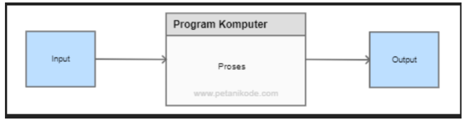

Nilai input bisa kita dapatkan dari keyboard, file, kamera, mikrofon, dan sebagainya.

Sementara output dapat kita tampilkan ke monitor, cetak ke dokumen, atau ke dalam sebuah file.

Pada tahap pemrosesan, program membutuhkan sebuah data untuk bisa melakukan pemrosesan. Untuk menyimpan data tersebut, kita membutuhkan wadah yang harus disesuaikan dengan tipe datanya, wadah tersebut kita sebut dengan Variabel.

Variabel adalah sebuah tempat menyimpan sebuah nilai. Sementara tipe data adalah jenis nilai yang akan tersimpan dalam variabel.

Anggap saja variabel itu sebuah wadah, lalu tipe data itu jenis-jenis benda yang akan disimpan dalam wadah tersebut.

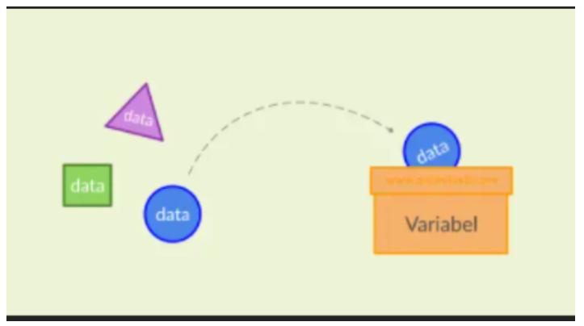

.

## D2. Aturan Penamaan Variabel Python

Penamaan suatu variabel pada python dapat dikatakan valid selama memenuhi aturan-aturan berikut:

- Nama dari sebuah variabel harus dimulai dengan huruf (a-z, A-Z) atau karakter garis bawah underscore (_) dan tidak dapat dimulai dengan angka (0-9).
- Variabel hanya boleh mengandung karakter alfabet dan bilangan dan underscore (a-z, A-Z, 0-9, _)
- Variabel bersifat case-sensitive yang mengartikan bahwa variabel TINGGI, tinggi, dan Tinggi merujuk pada tiga variabel berbeda.

Kemudian, selain dapat mendeklarasikan nilai dari suatu variabel secara baris per baris, juga dapat mendeklarasikan beberapa variabel dalam satu baris

```python
bil1, bil2 = 3, 4
bil3 = 5
salam = "Selamat malam"
penutup = "Terima kasih"

print(salam, bil2, penutup)
```

```
Selamat malam 4 Terima kasih
```

```python
#Cara mendapatkan data dari input user
variabelX = input("Masukan nilai variabel X : ")
print("Nilai variabel X adalah ", variabelX)
```

```
Masukan nilai variabel X : 12
Nilai variabel X adalah  12
```

.

## D3. Tipe Data Dasar : Null, Boolean, Numeric, Text

- Null Type: Tipe data null dalam Python digunakan untuk menyimpan nilai kosong atau tidak ada yang dinyatakan dengan None.
- Boolean Type: Tipe data boolean atau bool digunakan untuk menyimpan nilai kebenaran (True, False) dari suatu ekspresi logika.
- Numeric Type: Tipe data yang digunakan untuk menyimpan data berupa angka. Terdapat dua macam tipe data numeric, yaitu int untuk menyimpan bilangan bulat (e.g.: 0, 1, 2, 404, -500, -1000) dan float untuk menyimpan bilangan riil (e.g.: 0.5, 1.01, 2.05, 4.04)
- Text Type: Pada Python, tipe data string (str) digunakan untuk menyimpan data teks. Tipe data string dimulai dengan tanda kutip (baik kutip satu/ dua) dan diakhir dengan tanda kutip. Contoh: "Teks", "Contoh teks menggunakan Python", dan 'Teks pada Python'.

```python
#Deklarasi Variabel
tipe_null = ""
tipe_boolean = True
tipe_booleanX = False
tipe_boolean1 = 5 < 10
tipe_boolean2 = 5 > 10
tipe_int = 10
tipe_float = 10.0
tipe_str = "Sepuluh"

#Print nilai variabel
print (tipe_null) #output tidak menampilkan apa apa
print (tipe_boolean) #output menampilkan nilai kebenaran True atau 1
print (tipe_booleanX) #output menampilkan nilai kebenaran False atau 0
print (tipe_boolean1)
print (tipe_boolean2)
print (tipe_int)
print (tipe_float)
print (tipe_str)
```

```
True
False
True
False
10
10.0
Sepuluh
```

.

## D4. Dynamic Typing Python

Python adalah bahasa pemrograman bertipe dinamis (kebalikan dari Java dan C/C++ yang bertipe statis) artinya programmer tidak perlu mendefinisikan tipe data variabel saat memprogram.

.

#### - Dynamic Typing pada Python

Perhatikan contoh pendeklarasian variabel dalam bahasa Python berikut ini :

```
variabel = 4
print(variabel)
```

.

```
Output :
4
```

Kemudian kita ubah nilai variabel dengan angka 10.

```
variabel = 4
variabel = 10
print(variabel)
```

.

```
Output :
10
```

Outputnya berubah menjadi 10 karena nilai variabel1 yang awalnya 4 telah diubah menjadi 10.

Artinya variabel bisa diubah nilainya dengan nilai bertipe data sama (dalam kasus di atas adalah integer). Lalu bagaimana jika ingin mengubahnya dengan nilai bertipe data string?

```
variabel = 4
variabel = 10
variabel = "Hallo"
print(variabel)
```

.

```
Output :
Hallo
```

Outputnya memunculkan 'Hello'. Artinya variabel bisa diganti dengan tipe data yang berbeda.

Hal ini membuktikan bahwa Python bersifat Dynamic Typing.

.

#### - Static Typing Bahasa Lain

Perhatikan contoh pendeklarasian variabel dalam bahasa lain yang bersifat statis berikut ini :

```
int variabel1;
    variabel1 =12;             //variabel diisi nilai 12
cout<<variabel1;
```

.

```
Output :
12
```

Kemudian kita ubah nilai dari variabel tersebut menjadi 20.

```
int variabel1;
    variabel1 = 12;           //variabel diisi nilai 12
    variabel1 = 20;          //variabel diganti menjadi 20
cout<<variabel1;
```

.

```
Output :
20
```

Outputnya berubah menjadi 20 karena nilai variabel1 yang awalnya 12 telah diubah menjadi 20.

Artinya variabel1 bisa diubah nilainya dengan nilai bertipe data sama (dalam kasus di atas adalah integer). Lalu bagaimana jika ingin mengubahnya dengan nilai bertipe data string?

```
int variabel1;
    variabel1 = 12;                    //variabel diisi nilai 12
    variabel1 = 20;                    //variabel diganti menjadi 20
    variabel1 = "Hallo Python";        //variabel diganti menjadi "Hallo Python"
cout<<variabel1;
```

.

```
Output :
error: invalid conversion from ‘const char*’ to ‘int’
```

Outputnya Error, karena variabel1 telah dideklarasikan khusus untuk tipe data integer.

Artinya, perubahan nilai tidak bisa dilakukan jika dengan tipe data yang berbeda atau tidak sesuai.

.

## D5. Casting

Casting merupakan sebuah metode atau cara untuk menentukan tipe data variabel.

Walaupun Python merupakan bahasa yang menganut Dynamic Typing, namun bukan berarti tidak bisa menentukan tipe data dalam variabelnya. Penentuan tipe data variabel ini menggunakan casting.

Penggunaan casting pada Python dilakukan dalam fungsi konstruktor, karena dalam Python berlaku konsep "Everything in Python is an Object". Oleh karena itu Python menggunakan class untuk mendefinisikan tipe data termasuk tipe data primitifnya.

Note :

- Konstruktor adalah method untuk menginstansiasi objek (membuat objek). Tugasnya yaitu menginisialisasi (memberikan nilai) pada objek dari class tertentu.
- Class adalah cetak biru atau blueprint dari object. Class digunakan hanya untuk membuat kerangka dasar. Yang akan kita pakai nantinya adalah hasil cetakan dari class, yakni object.
- Object adalah hasil cetak dari class, atau hasil ‘konkrit’ dari class.

Contoh, jika menggunakan analogi class Laptop, maka objek dari class Laptop bisa berupa: laptop_andi, laptop_anto, laptop_zein, dan lain-lain. Objek dari class laptop akan memiliki karakteristik masing-masing yang mana dapat diinisialisasi melalui konstruktor.

```
(Selebihnya tentang konstruktor, class, dan objek, akan dijelaskan di materi Object Oriented Programming Python)
```

```python
#Membuat variabel x yang diisi oleh angka 2
x = 2
```

```python
#Cek tipe data dari x
type(x)
```

```
int
```

```python
#Melakukan casting sementara
float(x)
```

```
2.0
```

```python
#Jika casting dilakukan seperti itu, maka ketika dicek tipe data dari x tidak akan berubah
#karena dia mengubah nilai x ke float hanya sementara
#artinya nilai x yang asli tetap integer yang awal dideklarasikan
type(x)
```

```
int
```

```python
#Melakukan casting secara total
x = float(2)

#maka variabel x akan menjadi float
```

```python
#jika dicek tipe datanya maka akan float, karena variabel x sudah dicasting secara default dengan float
type(x)
```

```
float
```

.

## D6. Konsep String (String Lanjutan)

Dalam bahasa pemrograman lain, string itu adalah tipe data yang berisi kumpulan dari karakter. Artinya string dalam bahasa lain merupakan tipe data yang berbeda dengan char (tipe data yang hanya memuat satu karakter).

Dalam Python, string adalah segala sesuatu yang berada di dalam quotes atau tanda petik. String dalam Python merupakan segala sesuatu yang dibaca sebagai teks, berapapun jumlah karakter didalamnya jika data tersebut berbentuk teks (disisipkan dalam tanda kutip) maka itu adalah string.

```python
#Dideklarasikan variabel berisi nilai dengan tipe tertentu
nama = 'Zein' #string
huruf = 'a' #string
angka_string = '10' #string
angka_float_string = '10.0' #string
angka_numerik = 10 #numerik integer
angka_float_numerik = 10.0 #numerik float
```

```python
#Cek tipe data
print(type(nama))
print(type(angka_string))
print(type(angka_float_string))
print(type(angka_numerik))
print(type(angka_float_numerik))
```

```
<class 'str'>
<class 'str'>
<class 'str'>
<class 'int'>
<class 'float'>
```

```python
#Jika di print maka akan seperti berikut
print(nama)
print(huruf)
print(angka_string)
print(angka_float_string)
print(angka_numerik)
print(angka_float_numerik)
```

```
Zein
a
10
10.0
10
10.0
```

Jika dilihat secara sekilas, output antara string dan numerik tidak ada bedanya. Namun sebenarnya ada perbedaan yang sangat besar di antara keduanya.

Perbedaan dari string dan numerik adalah dalam pengoperasiannya.

String tidak dapat dioperasikan dengan operasi matematika atau perhitungan, namun numerik jelas bisa dioperasikan dengan operasi matematika.

```python
#Dideklarasikan variabel berisi nilai dengan tipe tertentu
nama = 'Zein' #string
huruf = ' a' #string
angka_string = '10' #string
angka_float_string = '10.0' #string
angka_numerik = 10 #numerik integer
angka_float_numerik = 10.0 #numerik float
```

```python
#Operasi '+' String dan String
print(nama + huruf)
```

```
Zein a
```

```python
#Operasi '+' numerik dan numerik
print(angka_numerik + angka_float_numerik)
```

```
20.0
```

```python
#Operasi '+' string dan numerik
print(angka_string + angka_numerik)
```

```
---------------------------------------------------------------------------
TypeError                                 Traceback (most recent call last)
<ipython-input-25-afffab655f0d> in <module>
      1 #Operasi '+' string dan numerik
----> 2 print(angka_string + angka_numerik)

TypeError: can only concatenate str (not "int") to str
```

```python
#Operasi '*' String dan numerik
print(angka_string * angka_numerik)
```

```
10101010101010101010
```

```python
#Operasi '*' String dan String
print(angka_string * nama)
```

```
---------------------------------------------------------------------------
TypeError                                 Traceback (most recent call last)
<ipython-input-27-bb266d20ec92> in <module>
      1 #Operasi '*' String dan String
----> 2 print(angka_string * nama)

TypeError: can't multiply sequence by non-int of type 'str'
```

```python
#Operasi '*' numerik dan numerik
print(angka_numerik * angka_float_numerik)
```

```
100.0
```

Dari contoh implementasi di atas, membuktikan bahwa perbedaan tipe data antara string dan numerik dapat berpengaruh terhadap penggunaan operator.

.

## D7. Penulisan String (String Lanjutan)

Ada dua cara menuliskan string, yaitu dengan single line dan multi line.

Penulisan single line cukup menggunakan satu buah tanda kutip satu

```
'..isi..'
```

atau satu buah tanda kutip dua

```
"..isi..".
```

Penulisan multi line menggunakan tiga buah tanda kutip satu

```
'''
...isi baris 1...
...isi baris 2...
'''
```

atau menggunakan tiga buah tanda kutip dua

```
"""
...isibaris 1...
...isibaris 2...
"""
```

```python
Teks1 = "ini adalah Zein"
Teks2 = '''
Ini adalah Zein.
Dia merupakan pemilik channel Petricode ini.
'''
```

```python
print(Teks1)
print(Teks2)
```

```
ini adalah Zein

Ini adalah Zein.
Dia merupakan pemilik channel Petricode ini.
```

Jika untuk menuliskan string kita dapat menggunakan '' atau "", lalu bagaimana jika kita ingin memasukan quotes atau kutipan di dalam string, seperti output ini : Ibu mengatakan "Selamat datang!" ??

Jawabannya adalah dengan menggunakan konsep character escape, yaitu memasukan tanda kutip-satu di dalam tanda kutip-dua atau sebaliknya.

```python
print("Ibu mengatakan 'Selamat datang!'")
```

```
Ibu mengatakan 'Selamat datang!'
```

```python
print('ibu mengatakan "Selamat datang!"')
```

```
ibu mengatakan "Selamat datang!"
```

```python
print('ibu mengatakan 'Selamat Datang!'') #jika menggunakan tanda kutip serupa maka akan error
```

```
  File "<ipython-input-33-3839f8ce738f>", line 1
    print('ibu mengatakan 'Selamat Datang!'') #jika menggunakan tanda kutip serupa maka akan error
                           ^
SyntaxError: invalid syntax
```

Lalu bagaimana jika kita ingin menampilkan output : He said, "What's there?" yang mana terdapat satu tanda kutip-satu di dalam kutipan dalam string?

Caranya bisa menggunakan tiga buah kutip atau menggunakan karakter escape.

Berikut adalah macam-macam karater escape :

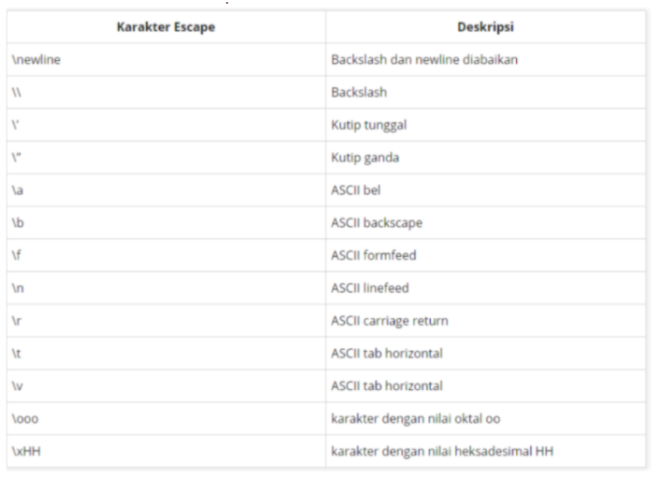

```python
#Contoh Penggunaan character escape
print('''He said, "What's there?"''')
print('He said, "What\'s there?"')
print("He said, \"What's there?\"")
print("C:\\Python34\\Lib")
print("Ini adalah baris pertama\nDan ini baris dua")
print("Ini adalah \x48\x45\x58")
```

```
He said, "What's there?"
He said, "What's there?"
He said, "What's there?"
C:\Python34\Lib
Ini adalah baris pertama
Dan ini baris dua
Ini adalah HEX
```